# SOLUTIONS: Building a simple linear regression table

Depression among adolescents in Jimma, Ethiopia

GRAPH Courses team

2026-07-05

# Introduction

These are the completed solutions for the week 7 exercise. Each step first shows the blanked chunk from the exercise (not run), then the filled-in **Solution** chunk that runs. In Part 2 we illustrate one possible choice of two extra predictors (place of residence and Oslo social support); any two of the three remaining predictors are acceptable.

In this exercise we build the **simple linear regression** column of a published table, using the study’s own data. We fit the first few rows together, then add more predictors, comparing our numbers to the paper and finding two places where the published table does not match a fresh analysis of the data.

## The study

- Girma et al. (2021), *Depression and its determinants among adolescents in Jimma town, Southwest Ethiopia*, PLOS ONE. A copy is in `paper/depression_paper.pdf`.
- The survey data the authors released is in `data/depression_data.xls`.

## The outcome: the PHQ-9 depression score

The authors measured depression with the **PHQ-9 (Patient Health Questionnaire-9)**, a widely used screening tool. It asks how often, over the last two weeks, a person has been bothered by nine problems, for example *“Little interest or pleasure in doing things”* and *“Feeling down, depressed, or hopeless.”* Each item is rated 0 (“Not at all”) to 3 (“Nearly every day”). The nine items are summed into a total from 0 to 27 (higher = more symptoms), which we rename to `depression_score`. Even though PHQ-9 is based on categorical item responses, composite scale scores like this are often treated as approximately continuous for modeling, and we follow that convention here to reproduce the paper’s linear regression analysis.

# PART 1: Build and check the first rows

## Load packages

Use `p_load()` to load: readxl, tidyverse, here, janitor, broom, gt.

*Exercise chunk (blank):*

```r
if (!require(pacman)) install.packages("pacman")
pacman::p_load(________)
```

**Solution:**

```r
if (!require(pacman)) install.packages("pacman")
pacman::p_load(readxl, tidyverse, here, janitor, broom, gt)
```

We also load the GRAPH Courses fork of the inspectdf package, which is currently unavailable on CRAN.

```r
pacman::p_load_gh("the-graph-courses/inspectdf")
```

## Step 1: Import, clean names, and label every predictor

Import the data and `glimpse()` it to see what we are working with.

```r
survey_raw <- read_excel(here("data/depression_data.xls"))
```

*Exercise chunk (blank):*

```r
________(survey_raw)
```

**Solution:**

```r
glimpse(survey_raw)
```

```
## Rows: 546
## Columns: 49
## $ IDAUTOMA   <dbl> 1, 2, 3, 4, 5, 6, 7, 8, 9, 10, 11, 12, 13, 14, 15, 16, 17, …
## $ AGECHRON   <dbl> 15, 16, 16, 15, 15, 18, 16, 16, 16, 16, 16, 15, 17, 15, 18,…
## $ SEXRESPO   <dbl> 0, 1, 0, 1, 0, 0, 0, 0, 0, 0, 0, 1, 1, 1, 1, 0, 0, 0, 0, 0,…
## $ GRADELEV   <dbl> 1, 1, 1, 1, 1, 2, 1, 1, 1, 1, 1, 1, 1, 1, 1, 1, 1, 1, 1, 1,…
## $ RELIGION   <dbl> 1, 1, 1, 1, 2, 1, 1, 1, 1, 1, 1, 1, 1, 1, 2, 1, 1, 1, 1, 2,…
## $ SCHOOLTY   <dbl> 1, 1, 1, 0, 1, 1, 1, 1, 1, 1, 1, 1, 1, 1, 1, 1, 1, 1, 1, 0,…
## $ FATHOCUO   <dbl> 4, 3, 3, 3, 1, 5, 3, 4, 3, 5, 2, 3, 4, 4, 3, 4, 3, 4, 4, 3,…
## $ MATHOCUO   <dbl> 3, 4, 5, 4, 1, 5, 3, 4, 5, 3, 2, 5, 4, 4, 3, 4, 3, 4, 5, 4,…
## $ FATHEDUE   <dbl> 4, 5, 3, 4, 5, 1, 3, 3, 3, 4, 4, 4, 3, 5, 5, 3, 4, 5, 3, 4,…
## $ MATHEDUE   <dbl> 3, 5, 4, 5, 5, 1, 3, 2, 3, 4, 3, 4, 3, 5, 5, 3, 4, 5, 3, 3,…
## $ RESIDECE   <dbl> 0, 0, 0, 0, 0, 0, 0, 0, 0, 0, 0, 0, 0, 0, 0, 0, 0, 0, 0, 0,…
## $ INTEREST   <dbl> 0, 0, 0, 1, 2, 1, 0, 2, 0, 1, 1, 3, 0, 0, 0, 1, 2, 1, 2, 0,…
## $ DEPRESSF   <dbl> 0, 1, 0, 3, 0, 1, 1, 3, 0, 0, 0, 2, 0, 3, 3, 1, 2, 0, 1, 0,…
```

[output cut: 36 more lines]

The raw column names are a little messy. We clean them, then subset to just the columns we will use.

```r
survey <- survey_raw %>%
  clean_names() %>%
  rename(
    depression_score = scoredep,
    chronological_age = agechron,
    oslo_social_support = osl3,
    sex = sexrespo,
    school_ownership = schoolty,
    residence = residece,
    grade_level = gradelev
  ) %>%
  select(
    depression_score,
    chronological_age, oslo_social_support,
    sex, school_ownership, residence, grade_level
  )

glimpse(survey)
```

```
## Rows: 546
## Columns: 7
## $ depression_score    <dbl> 0, 4, 3, 12, 5, 13, 8, 8, 5, 3, 2, 15, 0, 7, 4, 14…
## $ chronological_age   <dbl> 15, 16, 16, 15, 15, 18, 16, 16, 16, 16, 16, 15, 17…
## $ oslo_social_support <dbl> 10, 9, 7, 4, 10, 5, 11, 11, 14, 10, 12, 6, 8, 11, …
## $ sex                 <dbl> 0, 1, 0, 1, 0, 0, 0, 0, 0, 0, 0, 1, 1, 1, 1, 0, 0,…
## $ school_ownership    <dbl> 1, 1, 1, 0, 1, 1, 1, 1, 1, 1, 1, 1, 1, 1, 1, 1, 1,…
## $ residence           <dbl> 0, 0, 0, 0, 0, 0, 0, 0, 0, 0, 0, 0, 0, 0, 0, 0, 0,…
## $ grade_level         <dbl> 1, 1, 1, 1, 1, 2, 1, 1, 1, 1, 1, 1, 1, 1, 1, 1, 1,…
```

**Question**: Based on the study title and the list of variables above, which is the outcome variable in our dataset?

**Answer:** `depression_score` is the outcome. It is the PHQ-9 total the study set out to explain; the other variables are the potential determinants (predictors).

Let’s explore the cleaned data with `inspect_cat()` and `inspect_num()`.

[figure not shown]

```r
inspect_cat(survey) %>% show_plot() # no categorical variables at the moment
```

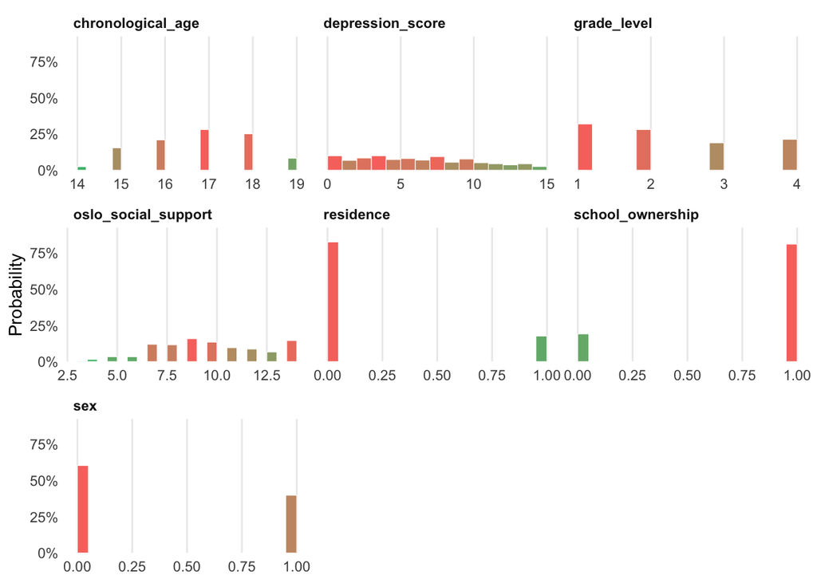

```r
inspect_num(survey) %>% show_plot()
```

Four of these predictors are categorical but stored as numeric codes, so we label them now, ordering the levels according to the paper.

*Exercise chunk (blanks):*

```r
survey <- survey %>%
  mutate(
    sex = factor(
      sex,
      levels = c(0, 1),
      labels = c("Female", "Male")
    ),
    school_ownership = factor(
      school_ownership,
      levels = c(0, 1),
      labels = ______
    ),
    residence = factor(
      residence,
      levels = c(0, 1),
      labels = ______
    ),
    grade_level = factor(
      grade_level,
      levels = c(1, 2, 3, 4),
      labels = ______
    )
  )
```

**Solution:**

```r
survey <- survey %>%
  mutate(
    sex = factor(
      sex,
      levels = c(0, 1),
      labels = c("Female", "Male")
    ),
    school_ownership = factor(
      school_ownership,
      levels = c(0, 1),
      labels = c("Private", "Public")
    ),
    residence = factor(
      residence,
      levels = c(0, 1),
      labels = c("Urban", "Rural")
    ),
    grade_level = factor(
      grade_level,
      levels = c(1, 2, 3, 4),
      labels = c("Grade 9", "Grade 10", "Grade 11", "Grade 12")
    )
  )
```

Now we can check again: the four labelled variables show up as categorical.

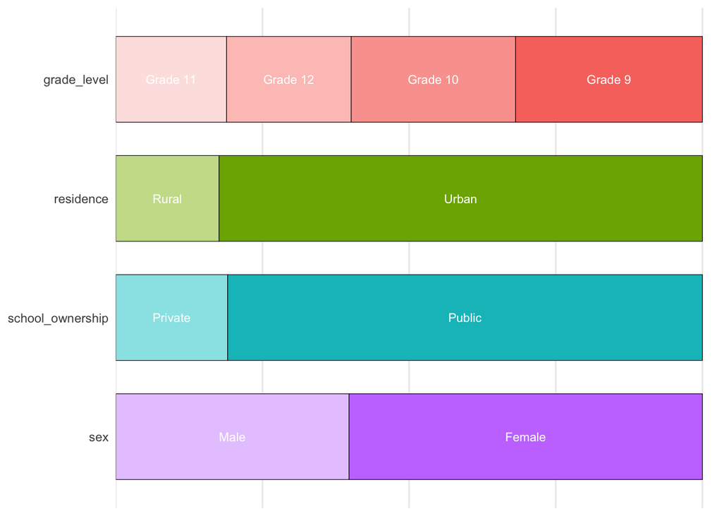

```r
inspect_cat(survey) %>% show_plot()
```

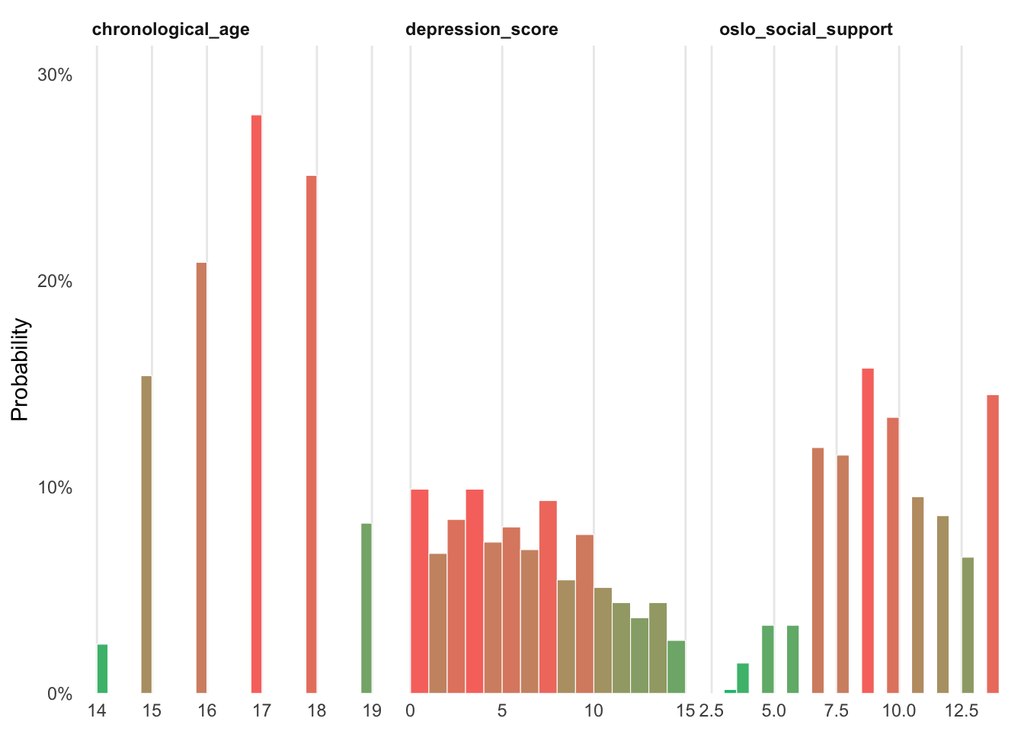

```r
inspect_num(survey) %>% show_plot()
```

**Question**: Which predictors are numeric/scale, binary, or polytomous?

**Answer:**

- Numeric/scale: `chronological_age`, `oslo_social_support`.
- Binary: `sex`, `school_ownership`, `residence`.
- Polytomous (3+ groups): `grade_level` (four grades).

## Step 2: Run one simple linear regression per predictor

*Exercise chunk (blanks):*

```r
age_model   <- lm(depression_score ~ chronological_age, data = survey)
sex_model   <- lm(___________ ~ ______, data = __________)
grade_model <- lm(___________ ~ ______, data = __________)
```

**Solution:**

```r
age_model   <- lm(depression_score ~ chronological_age, data = survey)
sex_model   <- lm(depression_score ~ sex, data = survey)
grade_model <- lm(depression_score ~ grade_level, data = survey)
```

```r
summary(sex_model)
```

```
##
## Call:
## lm(formula = depression_score ~ sex, data = survey)
##
## Residuals:
##     Min      1Q  Median      3Q     Max
## -7.0304 -3.2876 -0.3733  2.9696  8.6267
##
## Coefficients:
##             Estimate Std. Error t value Pr(>|t|)
## (Intercept)   7.0304     0.2218  31.694   <2e-16 ***
## sexMale      -0.6571     0.3519  -1.868   0.0624 .
## ---
## Signif. codes:  0 '***' 0.001 '**' 0.01 '*' 0.05 '.' 0.1 ' ' 1
##
## Residual standard error: 4.023 on 544 degrees of freedom
## Multiple R-squared:  0.006371,   Adjusted R-squared:  0.004544
## F-statistic: 3.488 on 1 and 544 DF,  p-value: 0.06236
```

**Question**: In `summary(sex_model)`, which sex is the reference group? Fill in the blanks in the sentence below to explain the relationship between sex and depression score.

**Answer:** Female is the reference group (the first factor level, folded into the intercept).

> The reference group is **Female**. The `sexMale` coefficient is about **-0.66**, which means that on average, males score about **0.66** points **lower** on the PHQ-9 than females.

(The coefficient keeps its minus sign, -0.66; the “points lower” phrase uses its size, 0.66, plus the direction word “lower”.)

## Step 3: Extract the beta and 95% CI with `broom`

```r
tidy(sex_model, conf.int = TRUE)
```

```
## # A tibble: 2 × 7
##   term        estimate std.error statistic   p.value conf.low conf.high
##   <chr>          <dbl>     <dbl>     <dbl>     <dbl>    <dbl>     <dbl>
## 1 (Intercept)    7.03      0.222     31.7  1.13e-125     6.59    7.47
## 2 sexMale       -0.657     0.352     -1.87 6.24e-  2    -1.35    0.0340
```

```r
tidy(grade_model, conf.int = TRUE)
```

```
## # A tibble: 4 × 7
##   term                estimate std.error statistic  p.value conf.low conf.high
##   <chr>                  <dbl>     <dbl>     <dbl>    <dbl>    <dbl>     <dbl>
## 1 (Intercept)            5.88      0.302     19.4  3.03e-64   5.29        6.47
## 2 grade_levelGrade 10    1.34      0.442      3.04 2.51e- 3   0.474       2.21
## 3 grade_levelGrade 11    0.878     0.496      1.77 7.73e- 2  -0.0964      1.85
## 4 grade_levelGrade 12    1.64      0.478      3.42 6.62e- 4   0.698       2.58
```

**Question**: What is the 95% CI for the `sexMale` coefficient? Fill in the blanks in the sentence below to interpret it.

**Answer:**

> The 95% CI for the `sexMale` coefficient (the male − female difference) runs from about **-1.35** to **0.03**. Because this interval **includes** 0, the difference **is not** statistically significant at the 0.05 level.

**Question**: The slope estimate for Grade 12 is 1.64. Fill in the blanks in the sentence below to explain the relationship between grade level and depression score.

**Answer:**

> Compared with **Grade 9** (the reference group), students in Grade 12 score about **1.64** points **higher** on the PHQ-9, on average.

### Helper for categorical predictors

Now, to turn these regression results into a paper-style table, we create some helper functions. Most of the formatting is written for you; as before, focus on getting the statistics right and check the values against the model output.

`cat_rows()` handles a categorical predictor: it drops the intercept, strips the variable name off `"sexMale"` to leave `"Male"`, and adds back a **reference row** with β = 0.

```r
cat_rows <- function(model, var_name, var_label, ref_label) {
  # non-reference rows: drop the intercept, clean the level label
  non_ref <- tidy(model, conf.int = TRUE) %>%
    filter(term != "(Intercept)") %>%
    mutate(level = str_remove(term, var_name)) %>%
    transmute(variable = var_label, level, beta = estimate, low = conf.low, high = conf.high)

  # the reference row: beta is 0 by definition, CI is blank
  ref <- tibble(variable = var_label, level = ref_label, beta = 0, low = NA_real_, high = NA_real_)

  bind_rows(ref, non_ref)
}
```

```r
cat_rows(sex_model, var_name = "sex", var_label = "Sex", ref_label = "Female")
```

```
## # A tibble: 2 × 5
##   variable level    beta   low    high
##   <chr>    <chr>   <dbl> <dbl>   <dbl>
## 1 Sex      Female  0     NA    NA
## 2 Sex      Male   -0.657 -1.35  0.0340
```

**Question**: Name one change that `cat_rows()` made compared with `tidy(sex_model, conf.int = TRUE)`.

**Answer:** It added a reference row for Female (β = 0, no CI), which `tidy()` did not show, and it cleaned the level label from `sexMale` to `Male` by stripping the variable name off the front. (It also renamed the columns and dropped the intercept row.)

### Helper for numeric/scale predictors

```r
cont_rows <- function(model, var_name, var_label, level_label) {
  tidy(model, conf.int = TRUE) %>%
    filter(term == var_name) %>%
    transmute(variable = var_label, level = level_label, beta = estimate, low = conf.low, high = conf.high)
}
```

```r
cont_rows(age_model, "chronological_age", "Chronological age", "Per 1-year increase")
```

```
## # A tibble: 1 × 5
##   variable          level                beta   low  high
##   <chr>             <chr>               <dbl> <dbl> <dbl>
## 1 Chronological age Per 1-year increase 0.447 0.181 0.714
```

### Build the first three rows

*Exercise chunk (blanks):*

```r
results <- bind_rows(
  cont_rows(age_model, "chronological_age", "Chronological age", "Per 1-year increase"),
  cat_rows(sex_model, "______", "Sex", ref_label = "______"),
  cat_rows(grade_model, "grade_level", "Grade level", ref_label = "Grade 9")
)

results
```

**Solution:**

```r
results <- bind_rows(
  cont_rows(age_model, "chronological_age", "Chronological age", "Per 1-year increase"),
  cat_rows(sex_model, "sex", "Sex", ref_label = "Female"),
  cat_rows(grade_model, "grade_level", "Grade level", ref_label = "Grade 9")
)

results
```

```
## # A tibble: 7 × 5
##   variable          level                 beta     low    high
##   <chr>             <chr>                <dbl>   <dbl>   <dbl>
## 1 Chronological age Per 1-year increase  0.447  0.181   0.714
## 2 Sex               Female               0     NA      NA
## 3 Sex               Male                -0.657 -1.35    0.0340
## 4 Grade level       Grade 9              0     NA      NA
## 5 Grade level       Grade 10             1.34   0.474   2.21
## 6 Grade level       Grade 11             0.878 -0.0964  1.85
## 7 Grade level       Grade 12             1.64   0.698   2.58
```

## Step 4: Assemble the table with `gt`

```r
make_table <- function(results_df) {
  results_df %>%
    mutate(
      `Beta (95% CI)` = if_else(
        is.na(low),
        "Reference",
        paste0(
          format(round(beta, 2), nsmall = 2), " (",
          format(round(low, 2), nsmall = 2), " to ",
          format(round(high, 2), nsmall = 2), ")"
        )
      )
    ) %>%
    select(variable, level, `Beta (95% CI)`) %>%
    gt(groupname_col = "variable", rowname_col = "level") %>%
    tab_header(
      title = "Depression (PHQ-9) score by participant characteristic",
      subtitle = "Simple (bivariable) linear regression"
    ) %>%
    tab_style(style = cell_text(weight = "bold"), locations = cells_row_groups()) %>%
    tab_options(table.width = pct(100))
}
```

```r
make_table(results)
```

Depression (PHQ-9) score by participant characteristic

Simple (bivariable) linear regression

|  | Beta (95% CI) |
| --- | --- |
| Chronological age |  |
| Per 1-year increase | 0.45 ( 0.18 to 0.71) |
| Sex |  |
| Female | Reference |
| Male | -0.66 (-1.35 to 0.03) |
| Grade level |  |
| Grade 9 | Reference |
| Grade 10 | 1.34 ( 0.47 to 2.21) |
| Grade 11 | 0.88 (-0.10 to 1.85) |
| Grade 12 | 1.64 ( 0.70 to 2.58) |

## Check these three rows against the paper

```r
results %>% filter(!is.na(low)) %>% mutate(across(c(beta, low, high), ~ round(.x, 2)))
```

```
## # A tibble: 5 × 5
##   variable          level                beta   low  high
##   <chr>             <chr>               <dbl> <dbl> <dbl>
## 1 Chronological age Per 1-year increase  0.45  0.18  0.71
## 2 Sex               Male                -0.66 -1.35  0.03
## 3 Grade level       Grade 10             1.34  0.47  2.21
## 4 Grade level       Grade 11             0.88 -0.1   1.85
## 5 Grade level       Grade 12             1.64  0.7   2.58
```

**Question**: Which of these three predictors matches the paper’s numbers?

**Answer:** **Sex** matches the paper exactly (Male β = -0.66, -1.35 to 0.03), but **chronological age** and **grade level** do not: the two errors we mentioned at the start.

For age, the data give β = 0.45 (0.18 to 0.71), but the paper prints 0.59 (0.20 to 0.99). For grade, with Grade 9 as the stated reference group, the data give Grade 10 = 1.34 (0.47 to 2.21) and Grade 12 = 1.64 (0.70 to 2.58), but the paper prints 0.63 and 0.95. (The paper’s table also drops the Grade 11 row altogether, even though those 103 students are in the data and in our model.)

If you find errors in published work, it is sometimes helpful to contact the authors and ask them to correct the table. For now, we ignore the errors and continue with the exercise.

# PART 2: Add two predictors of your own

We illustrate with **place of residence** (binary) and **Oslo social support** (numeric/scale). The Oslo score runs from 3 to 14, where higher means more social support; for this exercise, we treat it like a continuous predictor and interpret the coefficient per 1-point increase. Any two of the three remaining predictors work.

*Exercise chunk (blanks):*

```r
my_model_1 <-
my_model_2 <-
```

**Solution:**

```r
my_model_1 <- lm(depression_score ~ residence, data = survey)
my_model_2 <- lm(depression_score ~ oslo_social_support, data = survey)
```

*Exercise chunk (blanks):*

```r
my_row_1 <- ______
my_row_2 <- ______
```

**Solution:** residence is binary (use `cat_rows`), Oslo social support is a numeric/scale score treated like a continuous predictor (use `cont_rows`).

```r
my_row_1 <- cat_rows(my_model_1, "residence", "Place of residence", ref_label = "Urban")
my_row_2 <- cont_rows(my_model_2, "oslo_social_support", "Oslo social support", "Per 1-point increase")
```

Stack and inspect the two rows before binding into the full table.

```r
my_rows <- bind_rows(my_row_1, my_row_2)
my_rows
```

```
## # A tibble: 3 × 5
##   variable            level                  beta    low   high
##   <chr>               <chr>                 <dbl>  <dbl>  <dbl>
## 1 Place of residence  Urban                 0     NA     NA
## 2 Place of residence  Rural                 1.46   0.573  2.34
## 3 Oslo social support Per 1-point increase -0.616 -0.733 -0.499
```

```r
results_full <- bind_rows(results, my_rows)

results_full
```

```
## # A tibble: 10 × 5
##    variable            level                  beta     low    high
##    <chr>               <chr>                 <dbl>   <dbl>   <dbl>
##  1 Chronological age   Per 1-year increase   0.447  0.181   0.714
##  2 Sex                 Female                0     NA      NA
##  3 Sex                 Male                 -0.657 -1.35    0.0340
##  4 Grade level         Grade 9               0     NA      NA
##  5 Grade level         Grade 10              1.34   0.474   2.21
##  6 Grade level         Grade 11              0.878 -0.0964  1.85
##  7 Grade level         Grade 12              1.64   0.698   2.58
##  8 Place of residence  Urban                 0     NA      NA
##  9 Place of residence  Rural                 1.46   0.573   2.34
## 10 Oslo social support Per 1-point increase -0.616 -0.733  -0.499
```

```r
make_table(results_full)
```

Depression (PHQ-9) score by participant characteristic

Simple (bivariable) linear regression

|  | Beta (95% CI) |
| --- | --- |
| Chronological age |  |
| Per 1-year increase | 0.45 ( 0.18 to 0.71) |
| Sex |  |
| Female | Reference |
| Male | -0.66 (-1.35 to 0.03) |
| Grade level |  |
| Grade 9 | Reference |
| Grade 10 | 1.34 ( 0.47 to 2.21) |
| Grade 11 | 0.88 (-0.10 to 1.85) |
| Grade 12 | 1.64 ( 0.70 to 2.58) |
| Place of residence |  |
| Urban | Reference |
| Rural | 1.46 ( 0.57 to 2.34) |
| Oslo social support |  |
| Per 1-point increase | -0.62 (-0.73 to -0.50) |

**Question**: For each predictor you added, does its 95% CI include 0? What does this mean about the significance of the predictor?

**Answer:** Neither CI includes 0. Place of residence: Rural β = 1.46 (0.57 to 2.34). Oslo social support: β = -0.62 (-0.73 to -0.50). Because neither interval includes 0, both predictors are statistically significantly associated with the depression score at alpha = 0.05.

**Question**: Do your two added rows match the paper’s simple linear regression column?

**Answer:** Yes. Residence (Rural) 1.46 (0.57 to 2.34) matches exactly. Oslo social support -0.62 (-0.73 to -0.50) matches the paper’s -0.62 (-0.73 to -0.49) to two decimals; the only difference is the upper bound, where the raw value -0.4987 sits right on the -0.49/-0.50 rounding boundary.

# PART 3: One framework for t-tests, ANOVA, and numeric/scale predictors

Simple linear regression answers the same questions as a t-test and an ANOVA for categorical predictors, while also handling numeric/scale predictors those tests cannot.

## A binary predictor: regression and the t-test

A two-sample t-test compares two group means, asking whether the difference between them could plausibly be zero. Under equal variances, that test and the regression slope test are the same calculation.

```r
t.test(depression_score ~ sex, data = survey, var.equal = TRUE)
```

```
##
##  Two Sample t-test
##
## data:  depression_score by sex
## t = 1.8676, df = 544, p-value = 0.06236
## alternative hypothesis: true difference in means between group Female and group Male is not equal to 0
## 95 percent confidence interval:
##  -0.03404722  1.34829371
## sample estimates:
## mean in group Female   mean in group Male
##             7.030395             6.373272
```

```r
tidy(sex_model)
```

```
## # A tibble: 2 × 5
##   term        estimate std.error statistic   p.value
##   <chr>          <dbl>     <dbl>     <dbl>     <dbl>
## 1 (Intercept)    7.03      0.222     31.7  1.13e-125
## 2 sexMale       -0.657     0.352     -1.87 6.24e-  2
```

**Question**: Compare the p-value from `t.test()` with the p-value for `sexMale` in `tidy(sex_model)`. What do you notice?

**Answer:** They are the same, p = 0.062. The t statistics are equal in size (1.87) and differ only in sign, which reflects the order the groups are subtracted. The equal-variance two-sample t-test *is* a simple linear regression with a binary predictor.

**Question**: Compute the two group means and subtract female from male. Does it match the regression coefficient?

```r
survey %>%
  group_by(sex) %>%
  summarise(mean_dep = mean(depression_score))
```

```
## # A tibble: 2 × 2
##   sex    mean_dep
##   <fct>     <dbl>
## 1 Female     7.03
## 2 Male       6.37
```

**Answer:** Female mean ≈ 7.03, male mean ≈ 6.37. Male minus female ≈ -0.66, which is exactly the `sexMale` coefficient. The slope for a binary predictor is just the difference in group means.

## A polytomous predictor: regression and ANOVA

With more than two groups there is no single slope; `lm()` gives one coefficient per non-reference grade. A one-way ANOVA instead asks one overall question (is there any difference among the group means?), which is the F test at the bottom of `summary(grade_model)`.

```r
summary(aov(depression_score ~ grade_level, data = survey))
```

```
##              Df Sum Sq Mean Sq F value  Pr(>F)
## grade_level   3    234   78.04   4.902 0.00227 **
## Residuals   542   8629   15.92
## ---
## Signif. codes:  0 '***' 0.001 '**' 0.01 '*' 0.05 '.' 0.1 ' ' 1
```

```r
summary(grade_model)
```

```
##
## Call:
## lm(formula = depression_score ~ grade_level, data = survey)
##
## Residuals:
##     Min      1Q  Median      3Q     Max
## -7.2222 -3.2222 -0.5172  2.7778  9.1207
##
## Coefficients:
##                     Estimate Std. Error t value Pr(>|t|)
## (Intercept)           5.8793     0.3025  19.437  < 2e-16 ***
## grade_levelGrade 10   1.3429     0.4422   3.037 0.002506 **
## grade_levelGrade 11   0.8780     0.4960   1.770 0.077300 .
## grade_levelGrade 12   1.6379     0.4783   3.425 0.000662 ***
## ---
## Signif. codes:  0 '***' 0.001 '**' 0.01 '*' 0.05 '.' 0.1 ' ' 1
##
## Residual standard error: 3.99 on 542 degrees of freedom
## Multiple R-squared:  0.02642,    Adjusted R-squared:  0.02103
## F-statistic: 4.902 on 3 and 542 DF,  p-value: 0.002273
```

**Question**: Compare the p-value from the ANOVA with the p-value at the bottom of `summary(grade_model)`. What do you notice?

**Answer:** They are the same, p = 0.0023. The overall F test at the bottom of the regression summary is the one-way ANOVA.

**Question**: Do the ANOVA F statistic and the F statistic from `summary(grade_model)` match?

**Answer:** Yes, both are F = 4.90 (on 3 and 542 degrees of freedom). A one-way ANOVA is a simple linear regression with a categorical predictor.

# Optional challenge: add a forest plot using LLM assistance

The published table is clear, but some papers combine tables and graphics in one figure. For example, look at Fig 2 this paper: https://gh.bmj.com/content/10/12/e018739#F2

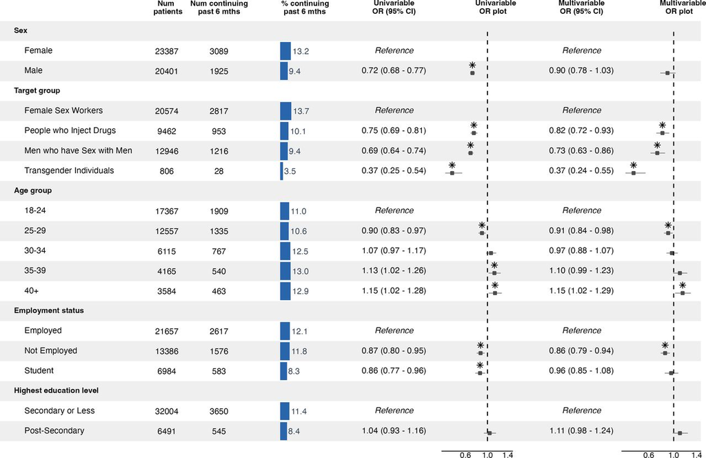

Example figure-table style with coefficient text and forest plots.

The authors shared this script that shows how to build such a table: https://github.com/kendavidn/yaounde_serocovpop_shared/blob/v1.0.0/scripts/infection_regn_2.R

We would like to replicate something like this for our own table. And we can use an LLM to help us with the code. We’d recommend using Claude or the paid version of ChatGPT for this. (Free ChatGPT may not be smart enough to handle the task.)

To prompt the LLM, you will probably want to paste your `results_full` data frame into the chat, as well as the link to the script (most modern LLMs can access such links). An example prompt could look like this:

> Here is my `results_full` table:

> {PASTE YOUR TABLE OUTPUT HERE}

> Please write R code to make a composite ggplot table with the coefficients, CIs, and a forest plot of these values. Add stars where the 95% CI excludes 0.

> Here is a link to a script that shows how to build such a table: https://github.com/kendavidn/yaounde_serocovpop_shared/blob/v1.0.0/scripts/infection_regn_2.R

When you run the LLM-generated code, if you get any errors, you can paste them back into the LLM chat to get help.

When done, be sure to check the values in the plot/table against the values in `results_full`.

# Summary